# Influence of Social Media and Stress on Students Academic Performance

### Team Members:

Rebecca Falash (rfalash) Michael Shahine (shahine) Mason Fisher (masonaf)

## Motivation:

We chose this topic for our project because we understand the pressures that come with being a student. As a team we wanted to better understand how outside factors can influence our mental health. We wanted to see what sort of habits have an effect on us as students and if there was any differences based off of things like age, gender, gpa etc. This is more and more relevant with the increasing amount of technology nowadays and the less and less time people are spending doing outside activities, making researching this even more important. We take a deeper look at this below and start to paint a picture.

#### Research Questions

1. Do male and female students preform differently under high stress ?
   - Is there a correlation between stress levels, age and GPA?

For this question I hope to learn if there is a significant different in academic perform between males and females in high stress environments. My hypothesis would say that there would be no significant difference in the way different genders handle stress in relation to the the final GPA but that older students may handle stress more efficiently then younger.

2. How does sleep quality relate to CGPA?
   - Is this relationship influenced by stress level and gender?

For this question I hope to learn if there is really a trend with sleep and GPA, I wonder if also different levels of stress and possibly gender make any difference. This would see if the time old question of 8 hours of sleep is relevant.

3. How does physical activity relate to depression levels across different age groups?
   - Is there correlation between depression levels and physical activity and how does that look among different age groups.

For this question I was hoping to see if theres any correlation with depression and activity levels especially among ages, as we become usually less active the older we get. This is especially more relevant with students during the school year, and in my own personal life during the winter.

## Data sources:

1. https://www.kaggle.com/datasets/jayaantanaath/student-habits-vs-academic-performance
2. https://www.kaggle.com/datasets/sonia22222/students-mental-health-assessments/data

These two datasets compliment each other because one captures behaviors and demographics such as social media usage, sleep, and study habits. While the other captures mental health outcomes such as stress, anxiety, and depression. When using both together you can study the connection between lifestyle factors, mental health, and academic performance in relation to age and gender.

```python
import pandas as pd
import kagglehub
import os
import matplotlib.pyplot as plt
import seaborn as sns

student_habits_URL = kagglehub.dataset_download(
    "jayaantanaath/student-habits-vs-academic-performance"
)

mental_health_URL = kagglehub.dataset_download(
    "sonia22222/students-mental-health-assessments"
)

filename1 = "student_habits_performance.csv"
filename2 = "students_mental_health_survey.csv"

full_path1 = os.path.join(student_habits_URL, filename1)
full_path2 = os.path.join(mental_health_URL, filename2)

df_habits = pd.read_csv(full_path1)
df_MH = pd.read_csv(full_path2)
```

[output not shown]

```
Downloading to C:\Users\mgsha\.cache\kagglehub\datasets\jayaantanaath\student-habits-vs-academic-performance\1.archive...
```

```
Extracting files...
```

```
Downloading to C:\Users\mgsha\.cache\kagglehub\datasets\sonia22222\students-mental-health-assessments\4.archive...
```

```
Extracting files...
```

## Data Description

**Variables of interest**

- Gender
- Age
- Mental_health_rating
- stress_level
- Depression_Score
- Anxiety_Score
- sleep_hours

**size of datasets and missing values**

- 'student_habits_performance.csv' (df_habits):
  - 1000 rows of data
  - 91 missing entries for parental_education_level
- 'students_mental_health_survey.csv' (df_MH):
  - 7022 rows of data
  - 12 missing values for CGPA
  - 15 missing values for Substance_Use

**Other Information**

The dataset has very little missing values so we did not have to remove any columns or rows before analysis.

We created 3 different filtered data frames to perform the analysis required to answer each question.

```python
df_habits.info()
```

```
<class 'pandas.core.frame.DataFrame'>
RangeIndex: 1000 entries, 0 to 999
Data columns (total 16 columns):
 #   Column                         Non-Null Count  Dtype
---  ------                         --------------  -----
 0   student_id                     1000 non-null   object
 1   age                            1000 non-null   int64
 2   gender                         1000 non-null   object
 3   study_hours_per_day            1000 non-null   float64
 4   social_media_hours             1000 non-null   float64
 5   netflix_hours                  1000 non-null   float64
 6   part_time_job                  1000 non-null   object
 7   attendance_percentage          1000 non-null   float64
 8   sleep_hours                    1000 non-null   float64
 9   diet_quality                   1000 non-null   object
 10  exercise_frequency             1000 non-null   int64
 11  parental_education_level       909 non-null    object
 12  internet_quality               1000 non-null   object
 13  mental_health_rating           1000 non-null   int64
 14  extracurricular_participation  1000 non-null   object
 15  exam_score                     1000 non-null   float64
dtypes: float64(6), int64(3), object(7)
memory usage: 125.1+ KB
```

```python
df_habits.isna().sum()
```

```
student_id                        0
age                               0
gender                            0
study_hours_per_day               0
social_media_hours                0
netflix_hours                     0
part_time_job                     0
attendance_percentage             0
sleep_hours                       0
diet_quality                      0
exercise_frequency                0
parental_education_level         91
internet_quality                  0
mental_health_rating              0
extracurricular_participation     0
exam_score                        0
dtype: int64
```

```python
df_MH.info()
```

```
<class 'pandas.core.frame.DataFrame'>
RangeIndex: 7022 entries, 0 to 7021
Data columns (total 20 columns):
 #   Column                       Non-Null Count  Dtype
---  ------                       --------------  -----
 0   Age                          7022 non-null   int64
 1   Course                       7022 non-null   object
 2   Gender                       7022 non-null   object
 3   CGPA                         7010 non-null   float64
 4   Stress_Level                 7022 non-null   int64
 5   Depression_Score             7022 non-null   int64
 6   Anxiety_Score                7022 non-null   int64
 7   Sleep_Quality                7022 non-null   object
 8   Physical_Activity            7022 non-null   object
 9   Diet_Quality                 7022 non-null   object
 10  Social_Support               7022 non-null   object
 11  Relationship_Status          7022 non-null   object
 12  Substance_Use                7007 non-null   object
 13  Counseling_Service_Use       7022 non-null   object
 14  Family_History               7022 non-null   object
 15  Chronic_Illness              7022 non-null   object
 16  Financial_Stress             7022 non-null   int64
 17  Extracurricular_Involvement  7022 non-null   object
 18  Semester_Credit_Load         7022 non-null   int64
 19  Residence_Type               7022 non-null   object
dtypes: float64(1), int64(6), object(13)
memory usage: 1.1+ MB
```

```python
df_MH.isna().sum()
```

```
Age                             0
Course                          0
Gender                          0
CGPA                           12
Stress_Level                    0
Depression_Score                0
Anxiety_Score                   0
Sleep_Quality                   0
Physical_Activity               0
Diet_Quality                    0
Social_Support                  0
Relationship_Status             0
Substance_Use                  15
Counseling_Service_Use          0
Family_History                  0
Chronic_Illness                 0
Financial_Stress                0
Extracurricular_Involvement     0
Semester_Credit_Load            0
Residence_Type                  0
dtype: int64
```

## Data Manipulation:

```python
df_habits = df_habits.rename(columns={"gender": "Gender", "age": "Age"})
new_HB_df = (
    df_habits.groupby(["Gender", "Age"])
    .agg(
        {
            "study_hours_per_day": "mean",
            "sleep_hours": "mean",
            "mental_health_rating": "mean",
        }
    )
    .reset_index()
)

new_SM_df = (
    df_MH.groupby(["Gender", "Age"])
    .agg(
        {
            "CGPA": "mean",
            "Stress_Level": "mean",
            "Depression_Score": "mean",
            "Anxiety_Score": "mean",
            "Financial_Stress": "mean",
        }
    )
    .reset_index()
)

data_merged = pd.merge(new_HB_df, new_SM_df, on=["Gender", "Age"])

data_merged
```

|  | Gender | Age | study_hours_per_day | sleep_hours | mental_health_rating | CGPA | Stress_Level | Depression_Score | Anxiety_Score | Financial_Stress |
| --- | --- | --- | --- | --- | --- | --- | --- | --- | --- | --- |
| 0 | Female | 18 | 3.884746 | 6.500000 | 5.627119 | 3.487614 | 2.486076 | 2.215190 | 2.281013 | 2.346835 |
| 1 | Female | 19 | 3.490164 | 6.527869 | 5.114754 | 3.511901 | 2.479339 | 2.311295 | 2.212121 | 2.418733 |
| 2 | Female | 20 | 3.644595 | 6.372973 | 6.175676 | 3.479396 | 2.285714 | 2.318681 | 2.362637 | 2.409341 |
| 3 | Female | 21 | 3.514286 | 6.357143 | 5.031746 | 3.475838 | 2.479058 | 2.264398 | 2.277487 | 2.486911 |
| 4 | Female | 22 | 3.633333 | 6.375000 | 5.200000 | 3.500716 | 2.500000 | 2.321429 | 2.205357 | 2.502976 |
| 5 | Female | 23 | 3.468627 | 6.547059 | 5.039216 | 3.473462 | 2.375000 | 2.355769 | 2.400641 | 2.375000 |
| 6 | Female | 24 | 3.454545 | 6.518182 | 5.218182 | 3.523243 | 2.440154 | 2.231660 | 2.320463 | 2.598456 |
| 7 | Male | 18 | 3.340741 | 6.338889 | 5.407407 | 3.493421 | 2.612245 | 2.314869 | 2.329446 | 2.504373 |
| 8 | Male | 19 | 3.475510 | 6.359184 | 5.938776 | 3.481470 | 2.585014 | 2.121037 | 2.299712 | 2.579251 |
| 9 | Male | 20 | 3.464615 | 6.301538 | 5.538462 | 3.468101 | 2.428969 | 2.261838 | 2.306407 | 2.373259 |
| 10 | Male | 21 | 3.347273 | 6.414545 | 5.054545 | 3.486624 | 2.422785 | 2.156962 | 2.263291 | 2.587342 |
| 11 | Male | 22 | 3.574510 | 6.545098 | 5.588235 | 3.509356 | 2.391061 | 2.167598 | 2.273743 | 2.458101 |
| 12 | Male | 23 | 3.600000 | 6.553226 | 5.112903 | 3.474863 | 2.478788 | 2.372727 | 2.215152 | 2.415152 |
| 13 | Male | 24 | 3.626389 | 6.612500 | 5.541667 | 3.481935 | 2.150000 | 2.271429 | 2.132143 | 2.571429 |

```python
### Standardize the gender column in both df's
df_MH.columns = df_MH.columns.str.strip().str.lower().str.replace(" ", "_")
df_habits.columns = df_habits.columns.str.strip().str.lower().str.replace(" ", "_")

### Check to make sure it worked
print(df_MH.columns)

### Look at distinct elements in both dataframes
print(df_MH["gender"].unique())
print(df_habits["gender"].unique())

merged_df = pd.merge(
    df_MH,
    df_habits,
    on="gender",
    how="inner"
)

print("Merged shape:", merged_df.shape)
merged_df.head()
```

```
Index(['age', 'course', 'gender', 'cgpa', 'stress_level', 'depression_score',
       'anxiety_score', 'sleep_quality', 'physical_activity', 'diet_quality',
       'social_support', 'relationship_status', 'substance_use',
       'counseling_service_use', 'family_history', 'chronic_illness',
       'financial_stress', 'extracurricular_involvement',
       'semester_credit_load', 'residence_type'],
      dtype='object')
['Male' 'Female']
['Female' 'Male' 'Other']
Merged shape: (3363394, 35)
```

|  | age_x | course | gender | cgpa | stress_level | depression_score | anxiety_score | sleep_quality | physical_activity | diet_quality_x | ... | part_time_job | attendance_percentage | sleep_hours | diet_quality_y | exercise_frequency | parental_education_level | internet_quality | mental_health_rating | extracurricular_participation | exam_score |
| --- | --- | --- | --- | --- | --- | --- | --- | --- | --- | --- | --- | --- | --- | --- | --- | --- | --- | --- | --- | --- | --- |
| 0 | 25 | Others | Male | 3.56 | 3 | 3 | 2 | Good | Moderate | Good | ... | No | 94.8 | 8.0 | Poor | 1 | High School | Poor | 1 | No | 34.3 |
| 1 | 25 | Others | Male | 3.56 | 3 | 3 | 2 | Good | Moderate | Good | ... | No | 82.9 | 7.4 | Fair | 1 | Master | Average | 4 | No | 100.0 |
| 2 | 25 | Others | Male | 3.56 | 3 | 3 | 2 | Good | Moderate | Good | ... | No | 71.7 | 7.9 | Fair | 2 | Bachelor | Average | 1 | No | 74.4 |
| 3 | 25 | Others | Male | 3.56 | 3 | 3 | 2 | Good | Moderate | Good | ... | No | 87.4 | 6.7 | Poor | 6 | Bachelor | Average | 9 | No | 78.9 |
| 4 | 25 | Others | Male | 3.56 | 3 | 3 | 2 | Good | Moderate | Good | ... | No | 97.5 | 6.5 | Good | 6 | High School | Average | 7 | No | 74.0 |

5 rows × 35 columns

```python
df_MH['age_group'] = pd.cut(
    df_MH['age'],
    bins=[17, 20, 23, 26, 30],
    labels=['18-20', '21-23', '24-26', '27+']
)

activity_depression_summary = (
    df_MH.groupby(['age_group', 'physical_activity'])
    .agg({
        'depression_score': 'mean',
        'gender': 'count'
    })
    .rename(columns={'gender': 'sample_size'})
    .reset_index()
)
display(activity_depression_summary)
```

|  | age_group | physical_activity | depression_score | sample_size |
| --- | --- | --- | --- | --- |
| 0 | 18-20 | High | 2.312500 | 448 |
| 1 | 18-20 | Low | 2.210769 | 650 |
| 2 | 18-20 | Moderate | 2.261883 | 1073 |
| 3 | 21-23 | High | 2.309406 | 404 |
| 4 | 21-23 | Low | 2.235759 | 632 |
| 5 | 21-23 | Moderate | 2.270195 | 1077 |
| 6 | 24-26 | High | 2.255738 | 305 |
| 7 | 24-26 | Low | 2.219858 | 423 |
| 8 | 24-26 | Moderate | 2.185339 | 723 |
| 9 | 27+ | High | 2.086957 | 184 |
| 10 | 27+ | Low | 2.310714 | 280 |
| 11 | 27+ | Moderate | 2.323404 | 470 |

## Data Visualization:

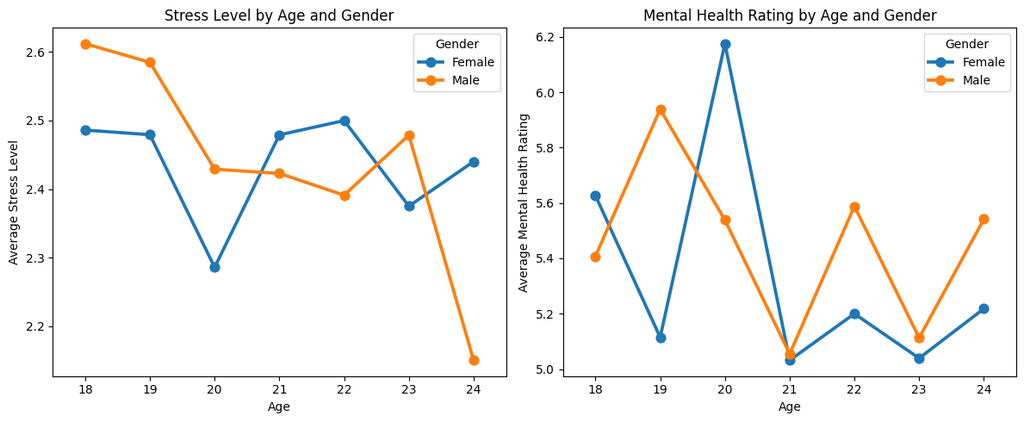

```python
fig, axes = plt.subplots(1, 2, figsize=(12, 5))

sns.pointplot(
    data=data_merged,
    x="Age",
    y="Stress_Level",
    hue="Gender",
    ax=axes[0],
)
axes[0].set_title("Stress Level by Age and Gender")
axes[0].set_xlabel("Age")
axes[0].set_ylabel("Average Stress Level")

sns.pointplot(
    data=data_merged,
    x="Age",
    y="mental_health_rating",
    hue="Gender",
    ax=axes[1],
)
axes[1].set_title("Mental Health Rating by Age and Gender")
axes[1].set_xlabel("Age")
axes[1].set_ylabel("Average Mental Health Rating")
axes[0].legend(title="Gender")

plt.tight_layout()
plt.show()
```

The plots above show the change in both the average mental health ratings and the average stress levels by age and gender.

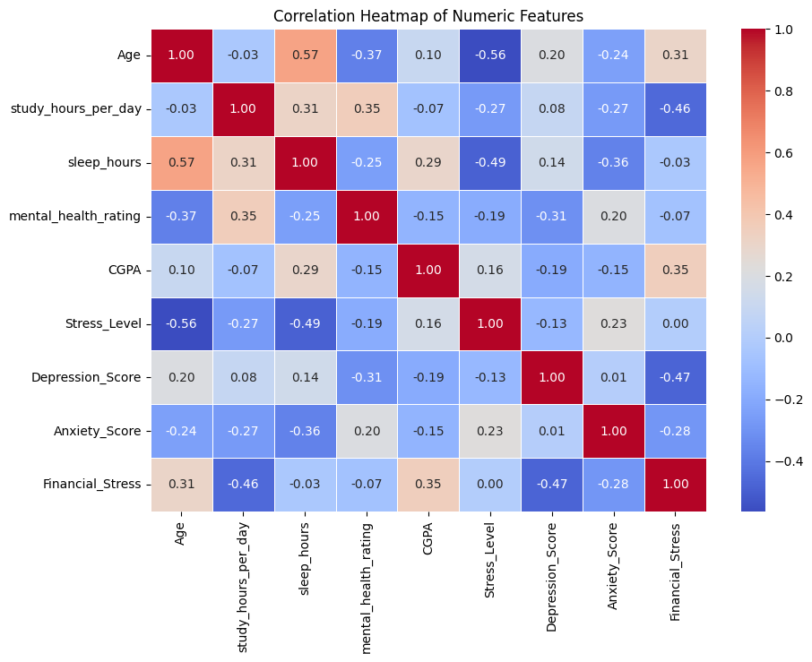

```python
numeric_cols = data_merged.select_dtypes(include="number")
corr_matrix = numeric_cols.corr()

plt.figure(figsize=(10, 7))
sns.heatmap(corr_matrix, annot=True, cmap="coolwarm", fmt=".2f", linewidths=0.5)
plt.title("Correlation Heatmap of Numeric Features")
plt.show()
```

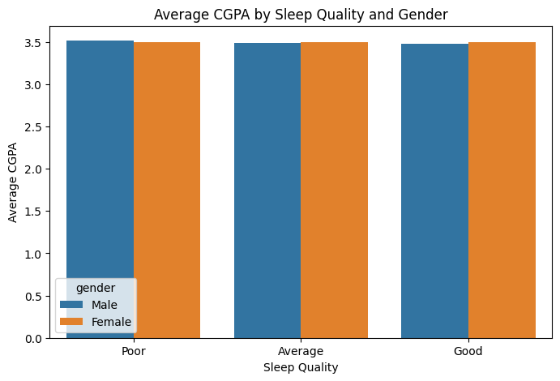

```python
plt.figure(figsize=(8,5))

sns.barplot(
    data=merged_df,
    x="sleep_quality",
    y="cgpa",
    hue="gender",
    order=["Poor", "Average", "Good"]
)

plt.title("Average CGPA by Sleep Quality and Gender")
plt.xlabel("Sleep Quality")
plt.ylabel("Average CGPA")

plt.show()
```

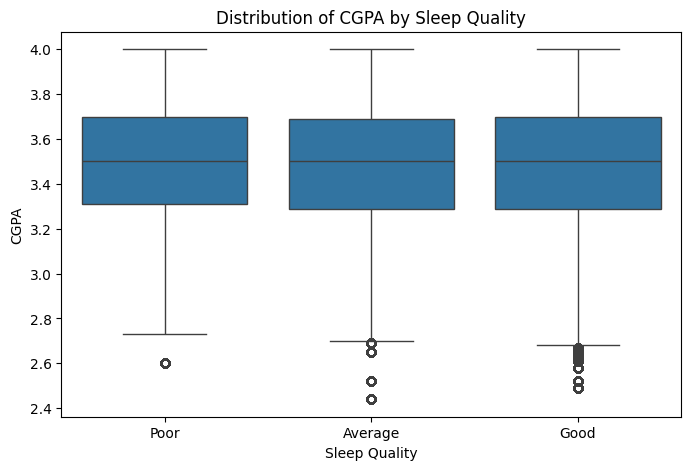

```python
plt.figure(figsize=(8,5))

sns.boxplot(
    data=merged_df,
    x="sleep_quality",
    y="cgpa",
    order=["Poor", "Average", "Good"]
)

plt.title("Distribution of CGPA by Sleep Quality")
plt.xlabel("Sleep Quality")
plt.ylabel("CGPA")

plt.show()
```

This plot above shows the distribution of the cumulative GPA's based on sleep quality.

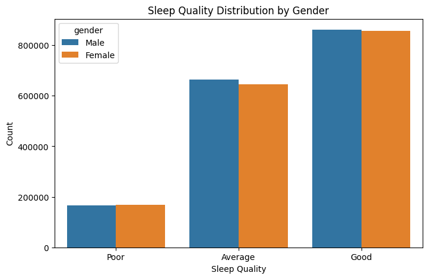

```python
plt.figure(figsize=(8,5))

sns.countplot(
    data=merged_df,
    x="sleep_quality",
    hue="gender",
    order=["Poor", "Average", "Good"]
)

plt.title("Sleep Quality Distribution by Gender")
plt.xlabel("Sleep Quality")
plt.ylabel("Count")

plt.show()
```

The plot above shows the sleep quality distribution by gender.

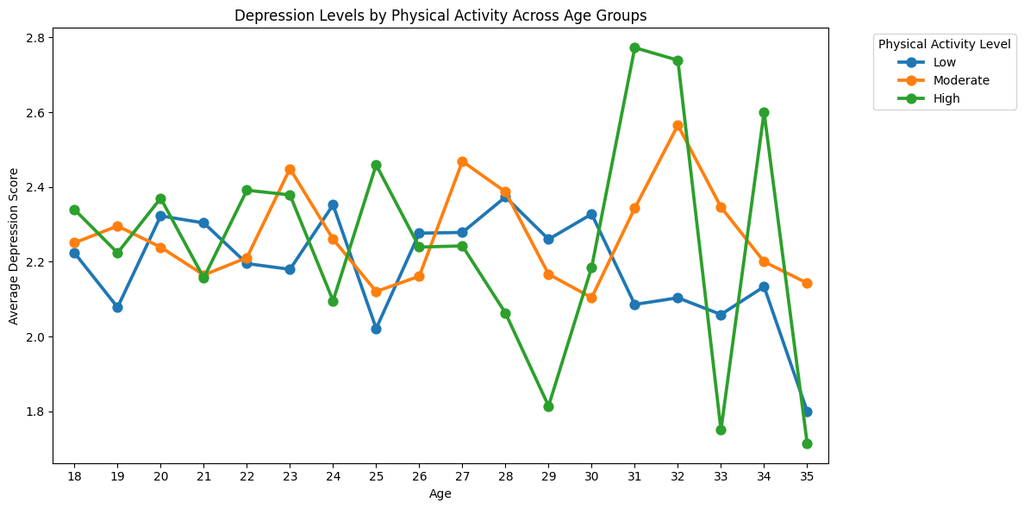

```python
plt.figure(figsize=(12, 6))

sns.pointplot(
    data=df_MH,
    x="age",
    y="depression_score",
    hue="physical_activity",
    errorbar=None

)

plt.title("Depression Levels by Physical Activity Across Age Groups")
plt.xlabel("Age")
plt.ylabel("Average Depression Score")
plt.legend(title="Physical Activity Level", bbox_to_anchor=(1.05, 1), loc='upper left')
plt.tight_layout()
plt.show()
```

This line plot shows how depression scores vary by physical activity level across different ages.

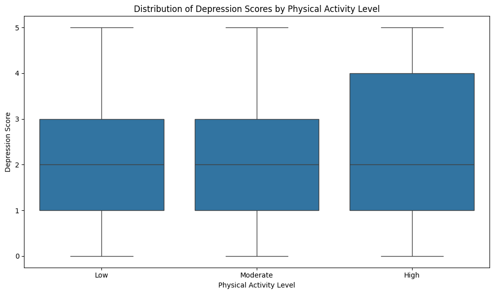

```python
plt.figure(figsize=(10, 6))

sns.boxplot(
    data=df_MH,
    x="physical_activity",
    y="depression_score",
    order=["Low", "Moderate", "High"]
)

plt.title("Distribution of Depression Scores by Physical Activity Level")
plt.xlabel("Physical Activity Level")
plt.ylabel("Depression Score")
plt.tight_layout()
plt.show()
```

This boxplot shows the distribution of depression scores for each physical activity level.

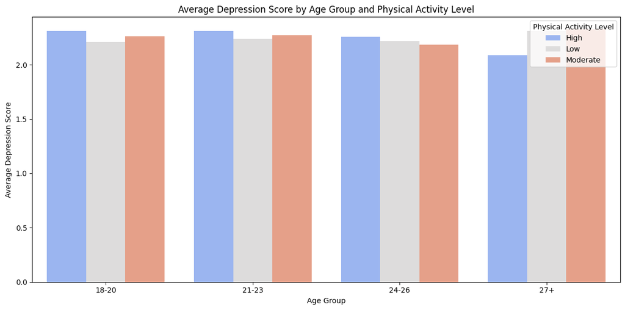

```python
plt.figure(figsize=(12, 6))

sns.barplot(
    data=df_MH.groupby(['age_group', 'physical_activity'])['depression_score'].mean().reset_index(),
    x='age_group',
    y='depression_score',
    hue='physical_activity',
    palette='coolwarm'
)

plt.title("Average Depression Score by Age Group and Physical Activity Level")
plt.xlabel("Age Group")
plt.ylabel("Average Depression Score")
plt.legend(title="Physical Activity Level")
plt.tight_layout()
plt.show()
```